# Variance decompositions and joint inference

Plagborg-Møller’s local-projection course: temperature shocks and world GDP (Bilal and Känzig), 1960–2019

Mikkel Plagborg-Møller’s short course *Local projections for applied macroeconomics* (2026) works one example through its Stata code: the effect of global temperature shocks on world GDP, after Bilal and Känzig (2026). This page reruns two of its steps that the package did not have: the **variance decomposition** of lecture 1, which asks how much of the GDP forecast error the temperature shock explains, and the **joint inference** of lecture 3, a Wald test of all horizons at once and a simultaneous confidence band. In Stata they take a loop of `regress`/`predict`, `suest` and a user-written command; here they are `implicitfevd`, `jointtest` and `bands = :supt`.

## Data and specification

The course’s extract of the Bilal–Känzig data ships as `docs/src/data/bilal_kanzig.csv`: annual, 1960–2019, with world real GDP per capita (100·log, `lnrgdppc_world_pwt`), the global temperature anomaly (`gtmp_bkly_aw_dtfe2s`, the Hamilton-filter forecast error of global temperature in °C), a global-recession indicator, the log oil price and the one-year Treasury yield.

```julia
bk = bk_data()
first(bk[:, [:year, :lnrgdppc_world_pwt, :gtmp_bkly_aw_dtfe2s, :recessiondates]], 3)
```

3×4 DataFrame

| Row | year Int64 | lnrgdppc_world_pwt Float64 | gtmp_bkly_aw_dtfe2s Float64 | recessiondates Int64 |
| --- | --- | --- | --- | --- |
| 1 | 1960 | 851.741 | -0.110203 | 0 |
| 2 | 1961 | 853.816 | -0.028175 | 0 |
| 3 | 1962 | 856.379 | -0.0481954 | 0 |

With $y_t$ log GDP, $x_t$ the anomaly, $r_t$ the recession indicator and $w_t$ the four lagged series, the local projection is

$$y_{t+h} = \mu_h + \theta_h x_t + \sum_{j=0}^{2} \gamma_{h,j} r_{t-j}
+ \sum_{j=1}^{2} \delta_{h,j}' w_{t-j} + \xi_{h,t+h}, \qquad h = 0, \dots, 10,$$

with heteroskedasticity-robust (HC1) standard errors, the course’s `reg ..., robust`. This is the argument of Montiel Olea and Plagborg-Møller (2021): once the projection controls for lags of the data (lag augmentation), the conventional heteroskedasticity-robust standard errors are valid, with no HAC correction and no bandwidth to choose. A recent version of the LP–VAR primer of Montiel Olea, Plagborg-Møller, Qian and Wolf (2025) goes one step further:

> The LP estimator should be bias-corrected using the procedure of Herbst and Johannsen (2024). Instead of reporting HAC standard errors for LP, simply report the conventional heteroskedasticity-robust standard errors—or even better, the bootstrap confidence interval discussed in Supplemental Appendix B.

The package has both: `biascorrect(m)` for the Herbst–Johannsen correction and `varbootstrap(m, data; vars, nlags)` for that bootstrap; the Ramey–Zubairy page applies them. This page stays with the course’s HC1 standard errors.

```julia
m = lp(@formula(leads(lnrgdppc_world_pwt) ~ gtmp_bkly_aw_dtfe2s + recessiondates +
                lags(recessiondates, 2) + lags(lnrgdppc_world_pwt, 2) +
                lags(gtmp_bkly_aw_dtfe2s, 2) + lags(lnpoil_wti, 2) + lags(treasury1y, 2)),
       bk; horizon = 10)
summarize(m; level = 0.68)
```

```
Impulse response of lnrgdppc_world_pwt to gtmp_bkly_aw_dtfe2s
╭─────────┬──────────┬──────────┬───────────┬───────────╮
│ Horizon │     Coef │ Std.Err. │ Lower 68% │ Upper 68% │
├─────────┼──────────┼──────────┼───────────┼───────────┤
│       0 │  -1.0136 │   1.3001 │   -2.3064 │    0.2793 │
│       1 │  -1.2826 │   1.8384 │   -3.1108 │    0.5457 │
│       2 │  -2.7903 │    2.151 │   -4.9294 │   -0.6513 │
│       3 │  -3.5777 │   2.4599 │    -6.024 │   -1.1314 │
│       4 │  -6.7294 │    3.092 │   -9.8043 │   -3.6546 │
│       5 │ -10.0739 │   3.8154 │  -13.8681 │   -6.2796 │
│       6 │ -11.5875 │   4.6065 │  -16.1685 │   -7.0064 │
│       7 │  -9.2609 │   4.9196 │  -14.1533 │   -4.3686 │
│       8 │  -9.5832 │   5.0433 │  -14.5985 │   -4.5678 │
│       9 │  -4.8635 │   6.0138 │   -10.844 │    1.1169 │
│      10 │  -2.0263 │   5.2064 │   -7.2039 │    3.1512 │
╰─────────┴──────────┴──────────┴───────────┴───────────╯
```

A 1 °C anomaly lowers world GDP per capita by 6.73% after four years and 11.59% after six.

## The implicit shock

By Frisch–Waugh, $\theta_h$ is the response to $\tilde x_t$, the residual of $x_t$ on all the controls: the movement in temperature that recessions and past economic conditions do not explain. `implicitshock` returns it, aligned with the rows of the data:

```julia
x̃ = implicitshock(m)
std(filter(isfinite, x̃))
```

```
0.10029931207558151
```

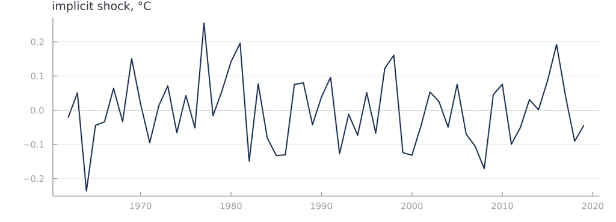

The implicit temperature shock (°C), the residual of the anomaly on the controls.

Its standard deviation, 0.10 °C, is the size of a typical shock, so a 1 °C impulse is about 10 standard deviations, an unusually large one.

## Variance decomposition

How much of the uncertainty about future GDP is due to temperature shocks? The course’s recipe, a version of Gorodnichenko and Lee (2020), runs at each horizon two regressions:

1. regress $y_{t+h}$ on the controls (everything but $x_t$) and keep the forecast error $\hat f_{h,t+h}$;
2. regress $\hat f_{h,t+h}$ on a constant and $\tilde x_t, \tilde x_{t+1}, \dots, \tilde x_{t+h}$; the share is its $R^2$.

The share is the fraction of the forecast-error variance that would disappear if the current and future shocks were known. `implicitfevd` runs both steps from the fitted projection:

```julia
fv = implicitfevd(m)
```

```
ImplicitFEVD (R² of the forecast error on the implicit shock)
  Response:   lnrgdppc_world_pwt
  Shock:      gtmp_bkly_aw_dtfe2s (residual on the controls, 58 rows)
  Formula:    :(leads(lnrgdppc_world_pwt)) ~ gtmp_bkly_aw_dtfe2s + recessiondates + :(lags(recessiondates, 2)) + :(lags(lnrgdppc_world_pwt, 2)) + :(lags(gtmp_bkly_aw_dtfe2s, 2)) + :(lags(lnpoil_wti, 2)) + :(lags(treasury1y, 2))
Forecast-error variance share of gtmp_bkly_aw_dtfe2s
╭─────────┬────────┬─────╮
│ Horizon │  Share │ Obs │
├─────────┼────────┼─────┤
│       0 │ 0.0082 │  58 │
│       1 │ 0.0267 │  57 │
│       2 │ 0.0851 │  56 │
│       3 │ 0.1052 │  55 │
│       4 │ 0.1846 │  54 │
│       5 │ 0.3068 │  53 │
│       6 │ 0.4492 │  52 │
│       7 │ 0.4916 │  51 │
│       8 │ 0.4603 │  50 │
│       9 │ 0.4599 │  49 │
│      10 │ 0.4383 │  48 │
╰─────────┴────────┴─────╯
```

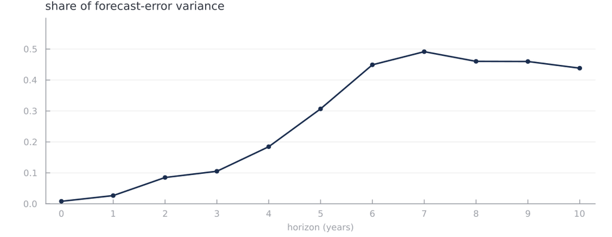

Share of the forecast-error variance of world GDP due to temperature shocks.

Temperature shocks explain 8.5% of the variance of the two-year GDP forecast error and 49.2% of the seven-year one, the figures on the course’s slides.

The package’s `fevd`, the port of Gorodnichenko and Lee’s own code, would not accept this specification as it stands: it treats the shock as observed and demeaned rather than residualized, conditions only on lagged variables, and needs a `cumul` or `ldiff` response. `implicitfevd` follows the course instead: the shock is $\tilde x_t$, the forecast error conditions on the contemporaneous recession indicator too, and the $R^2$ is the centred one of a regression with a constant. It has no standard errors, as in the course.

## Joint inference across horizons

The 68% band above covers each horizon with probability 0.68 *separately*. A hypothesis about several horizons needs the covariance of the estimates across horizons, which are correlated because the regressions share their observations. `jointvcov` stacks the scores of every horizon on one time axis (Stata’s `suest`), and `jointtest` is the Wald test that the response is zero at every horizon:

```julia
t = jointtest(m)
```

```
Joint Wald test across horizons
  Term:       gtmp_bkly_aw_dtfe2s
  H₀:         θ_h = 0 for h ∈ {0:10}
  Vcov:       CovarianceMatrices.HR1()
  chi2(11) = 23.1552
  p-value:    0.0168
```

The estimates are strongly correlated across neighbouring horizons (the correlation of $\hat\theta_5$ and $\hat\theta_6$ is 0.85), so the pointwise band cannot be read as a joint statement. The null of no effect at any horizon is rejected with a p-value of 0.017.

A **simultaneous** band covers the whole response with probability 0.68. The sup-t band of Montiel Olea and Plagborg-Møller (2019) widens the pointwise band by a common critical value, the 68% quantile of $\max_h |\hat\theta_h - \theta_h| / \mathrm{se}_h$, simulated from that correlation:

```julia
c68 = supt_critical_value(m; level = 0.68)
```

```
1.8771803288591733
```

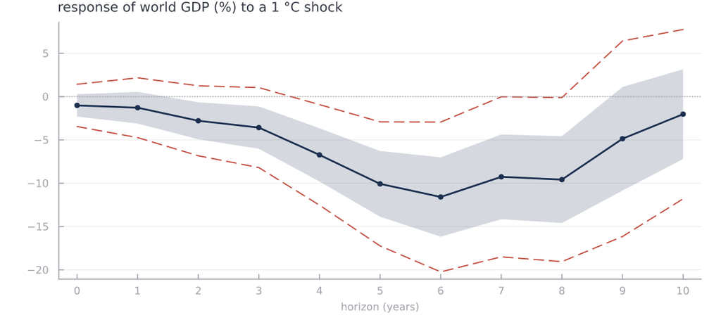

Response of world GDP per capita (%) to a 1 °C temperature shock: 68% pointwise band (shaded) and 68% sup-t simultaneous band (dashed).

The simultaneous band uses 1.88 standard errors instead of one. It still excludes zero at horizons 4–8, so the negative effect of temperature shocks on GDP survives the joint reading. At the 90% level (critical value 2.42) it excludes zero at horizons 5–6. Any shape restriction can be checked the same way: a monotone response, for instance, is rejected if no monotone function fits inside the band.

`bands = :supt` works in `summarize`, `plot` and `irfplot` alike:

```julia
summarize(m; level = 0.68, bands = :supt)
plot(m; levels = [0.68], bands = :supt)
```

With an `EWC(B)` estimator the test becomes the fixed-smoothing $F_{m,\,B-m+1}$ test and the sup-t draws come from the fixed-$b$ limit, whose margins are Student-$t_B$. With $T = 58$ the LLSW rule gives only 6 cosine terms, fewer than the eleven horizons, and an EWC variance has rank at most $B$, so the joint test is available only for a few horizons at a time:

```julia
jointtest(m, EWC(ewc_bandwidth(m)); horizons = 4:8)
```

```
Joint Wald test across horizons
  Term:       gtmp_bkly_aw_dtfe2s
  H₀:         θ_h = 0 for h ∈ {4:8}
  Vcov:       CovarianceMatrices.EWC(6)
  F(5, 2) = 1.186   (Wald = 17.7899, fixed-b EWC)
  p-value:    0.5164
```